# HEART DISEASE

MELİS MERVE DOGANCAY

11/22/2020

## 1.VERİ SETİ HAZIRLANMASI:

$\bullet$ Age= yaş değişkeni

$\bullet$ Sex= Cinsiyet değişkeni(1=erkek,0=kadın)

$\bullet$ cp= göğüs ağrısı tipi

$\bullet$ trestbps= dinlenme kan basıncı (hastaneye kabul edildiğinde mm Hg cinsinden)

$\bullet$ chol= mg / dl cinsinden serum kolestoral

$\bullet$ fbs= açlık kan şekeri>120 mg / dl (1=doğru, 0=yanlış)

$\bullet$ restecg= dinlenme elektrokardiyografik (EKG) sonuçları

$\bullet$ thalach= ulaşılan maksimum kalp atış hızı

$\bullet$ exang= egzersize bağlı anjina (1= ağrı var, 0= ağrı yok)

$\bullet$ oldpeak= Dinlenmeye göre egzersizin neden olduğu ST depresyonu

$\bullet$ slope= tepe egzersiz St segmentinin eğimi.(1= yukarı eğimli, 2=düz, 3=aşağı eğimli)

$\bullet$ ca= flourosopi ile renklendirilmiş büyük damarların sayısı

$\bullet$ thal= (3= normal, 6= değişmez kusur, 7= tersine çevrilebilir kusur

$\bullet$ num= kalp hastalığı teşhisi (YES= hasta, NO= hasta değil)

303 gözlem ve 14 değişken üzerinden veri analizi yapılacaktır. Veri analizinin amacı, Kalp rahatsızlığı olanlar ile olmayanları güvenilir bir şekilde ayırabilen bir sınıflandırıcı geliştirmektir. Hedef değişken yani bağımlı değişken num değişkenidir.

Öncelikle veri setinin %70’i eğitim ve %30’u test verisi olmak üzere ikiye ayırıldı sonrasında eğitim verisi üzerinde 10-katlı çapraz doğrulama (10-fold cross validation) kullanılarak verinin analizi yapıldı.

Eğitim veri seti üzerinde modelleme yapıldı ve test veri seti üzerinde de accuracy hesaplandı.

## 1.1 VERİNİN OKUTULMASI VE DEĞİŞKENLERİN DÜZENLENMESİ:

```r
getwd()
setwd("~/Desktop/UCI-HEART DISEASE")
heart = read.csv(file ="processed.cleveland.txt",sep=",",header = T)
```

```r
head(heart)
```

```
##   Age sex cp trestbps chal fbs restecg thalach exang oldpeak slope  ca
## 1  63   1  1      145  233   1       2     150     0     2.3     3 0.0
## 2  67   1  4      160  286   0       2     108     1     1.5     2 3.0
## 3  67   1  4      120  229   0       2     129     1     2.6     2 2.0
## 4  37   1  3      130  250   0       0     187     0     3.5     3 0.0
## 5  41   0  2      130  204   0       2     172     0     1.4     1 0.0
## 6  56   1  2      120  236   0       0     178     0     0.8     1 0.0
##   thal num
## 1  6.0   0
## 2  3.0   2
## 3  7.0   1
## 4  3.0   0
## 5  3.0   0
## 6  3.0   0
```

```r
num=ifelse(heart$num==0,1,0)
heart=heart[,-14]
heart=cbind(heart,num)
heart$num=as.factor(heart$num)
levels(heart$num)=c('YES','NO')
heart$sex=as.factor(heart$sex)
heart$cp=as.factor(heart$cp)
heart$fbs=as.factor(heart$fbs)
heart$restecg=as.factor(heart$restecg)
heart$slope=as.factor(heart$slope)
heart$exang=as.factor(heart$exang)
head(heart)
```

```
##   Age sex cp trestbps chal fbs restecg thalach exang oldpeak slope  ca
## 1  63   1  1      145  233   1       2     150     0     2.3     3 0.0
## 2  67   1  4      160  286   0       2     108     1     1.5     2 3.0
## 3  67   1  4      120  229   0       2     129     1     2.6     2 2.0
## 4  37   1  3      130  250   0       0     187     0     3.5     3 0.0
## 5  41   0  2      130  204   0       2     172     0     1.4     1 0.0
## 6  56   1  2      120  236   0       0     178     0     0.8     1 0.0
##   thal num
## 1  6.0  NO
## 2  3.0 YES
## 3  7.0 YES
## 4  3.0  NO
## 5  3.0  NO
## 6  3.0  NO
```

```r
summary(heart)
```

```
##       Age        sex     cp         trestbps          chal       fbs
##  Min.   :29.00   0: 97   1: 23   Min.   : 94.0   Min.   :126.0   0:258
##  1st Qu.:48.00   1:206   2: 50   1st Qu.:120.0   1st Qu.:211.0   1: 45
##  Median :56.00           3: 86   Median :130.0   Median :241.0
##  Mean   :54.44           4:144   Mean   :131.7   Mean   :246.7
##  3rd Qu.:61.00                   3rd Qu.:140.0   3rd Qu.:275.0
##  Max.   :77.00                   Max.   :200.0   Max.   :564.0
##  restecg    thalach      exang      oldpeak     slope     ca
##  0:151   Min.   : 71.0   0:204   Min.   :0.00   1:142   ?  :  4
##  1:  4   1st Qu.:133.5   1: 99   1st Qu.:0.00   2:140   0.0:176
##  2:148   Median :153.0           Median :0.80   3: 21   1.0: 65
##          Mean   :149.6           Mean   :1.04           2.0: 38
##          3rd Qu.:166.0           3rd Qu.:1.60           3.0: 20
##          Max.   :202.0           Max.   :6.20
##   thal      num
##  ?  :  2   YES:139
##  3.0:166   NO :164
##  6.0: 18
##  7.0:117
##
##
```

## 1.2 VERİDEKİ KAYIP DEĞERLERİN DÜZENLENMESİ:

```r
which(heart$ca=="?")
```

```
## [1] 167 193 288 303
```

```r
which(heart$thal=="?")
```

```
## [1]  88 267
```

```r
levels(heart$ca)=c(0,0,1,2,3)
levels(heart$thal)=c(3,3,6,7)
```

$\bullet$ Veride ca değişkenin de 4, thal değişkeninde 2 olmak üzere toplam 6 tane kayıp değer bulundu. Kayıp değerlere değişkenler de en çok aldıkları değerlere göre değer verildi.(ca değişkeninin mode’u 0, thal değişkeninin mode’u 3 olduğundan kayıp değerlere bu değerler verildi.)

## 1.3 VERİNİN ÖZETİ:

```r
summary(heart)
```

```
##       Age        sex     cp         trestbps          chal       fbs
##  Min.   :29.00   0: 97   1: 23   Min.   : 94.0   Min.   :126.0   0:258
##  1st Qu.:48.00   1:206   2: 50   1st Qu.:120.0   1st Qu.:211.0   1: 45
##  Median :56.00           3: 86   Median :130.0   Median :241.0
##  Mean   :54.44           4:144   Mean   :131.7   Mean   :246.7
##  3rd Qu.:61.00                   3rd Qu.:140.0   3rd Qu.:275.0
##  Max.   :77.00                   Max.   :200.0   Max.   :564.0
##  restecg    thalach      exang      oldpeak     slope   ca      thal
##  0:151   Min.   : 71.0   0:204   Min.   :0.00   1:142   0:180   3:168
##  1:  4   1st Qu.:133.5   1: 99   1st Qu.:0.00   2:140   1: 65   6: 18
##  2:148   Median :153.0           Median :0.80   3: 21   2: 38   7:117
##          Mean   :149.6           Mean   :1.04           3: 20
##          3rd Qu.:166.0           3rd Qu.:1.60
##          Max.   :202.0           Max.   :6.20
##   num
##  YES:139
##  NO :164
##
##
##
##
```

```r
by(heart, heart$num, summary)
```

```
## heart$num: YES
##       Age        sex     cp         trestbps          chal       fbs
##  Min.   :35.00   0: 25   1:  7   Min.   :100.0   Min.   :131.0   0:117
##  1st Qu.:52.00   1:114   2:  9   1st Qu.:120.0   1st Qu.:217.5   1: 22
##  Median :58.00           3: 18   Median :130.0   Median :249.0
##  Mean   :56.63           4:105   Mean   :134.6   Mean   :251.5
##  3rd Qu.:62.00                   3rd Qu.:145.0   3rd Qu.:283.5
##  Max.   :77.00                   Max.   :200.0   Max.   :409.0
##  restecg    thalach      exang     oldpeak      slope  ca     thal
##  0:56    Min.   : 71.0   0:63   Min.   :0.000   1:36   0:47   3:38
##  1: 3    1st Qu.:125.0   1:76   1st Qu.:0.550   2:91   1:44   6:12
##  2:80    Median :142.0          Median :1.400   3:12   2:31   7:89
##          Mean   :139.3          Mean   :1.574          3:17
##          3rd Qu.:156.5          3rd Qu.:2.500
##          Max.   :195.0          Max.   :6.200
##   num
##  YES:139
##  NO :  0
##
##
##
##
## --------------------------------------------------------
## heart$num: NO
##       Age        sex    cp        trestbps          chal       fbs
##  Min.   :29.00   0:72   1:16   Min.   : 94.0   Min.   :126.0   0:141
##  1st Qu.:44.75   1:92   2:41   1st Qu.:120.0   1st Qu.:208.8   1: 23
##  Median :52.00          3:68   Median :130.0   Median :234.5
##  Mean   :52.59          4:39   Mean   :129.2   Mean   :242.6
##  3rd Qu.:59.00                 3rd Qu.:140.0   3rd Qu.:267.2
##  Max.   :76.00                 Max.   :180.0   Max.   :564.0
##  restecg    thalach      exang      oldpeak       slope   ca      thal
##  0:95    Min.   : 96.0   0:141   Min.   :0.0000   1:106   0:133   3:130
##  1: 1    1st Qu.:148.8   1: 23   1st Qu.:0.0000   2: 49   1: 21   6:  6
##  2:68    Median :161.0           Median :0.2000   3:  9   2:  7   7: 28
##          Mean   :158.4           Mean   :0.5866           3:  3
##          3rd Qu.:172.0           3rd Qu.:1.0250
##          Max.   :202.0           Max.   :4.2000
##   num
##  YES:  0
##  NO :164
##
##
##
##
```

$\bullet$ Burada hasta olan ve hasta olmayan gözlemlere göre değişkenlerin tanımlayıcı istatistikleri verilmiştir.

```r
table(heart$num)/nrow(heart)*100
```

```
##
##      YES       NO
## 45.87459 54.12541
```

$\bullet$ Veride 303 gözlemin %45’i hasta iken %54’ü hasta değildir.

## 2.VERİ ANALİZİ:

## 2.1 VERİNİN EĞİTİM VE TEST SETİ OLARAK AYRILMASI:

```r
library(caret)
library(randomForest)
set.seed(123)
train_ind <- createDataPartition(heart$num,p=0.7,list=FALSE)
trainSet <- heart[train_ind,]
testSet <- heart[-train_ind,]
```

```r
dim(trainSet)
```

```
## [1] 213  14
```

```r
dim(testSet)
```

```
## [1] 90 14
```

$\bullet$ Veri, eğitim veri setinde 213 gözlem, test veri setinde ise 90 gözlem olacak şekilde ayrılmıştır.

```r
train_control <- trainControl(method = "cv", number = 10,savePredictions = T,classProbs = T,summaryFunction = twoClassSummary)
```

# 2.2 LOJİSTİK REGRESYON MODELİ:

```r
model_logreg <- train(num~.,data = trainSet,trControl=train_control,
                      method="glm",family="binomial",preProc=c("center","scale"),metric="ROC")
summary(model_logreg)
```

```
##
## Call:
## NULL
##
## Deviance Residuals:
##     Min       1Q   Median       3Q      Max
## -2.8867  -0.1731   0.0774   0.3956   2.3329
##
## Coefficients:
##             Estimate Std. Error z value Pr(>|z|)
## (Intercept) -0.03665    0.26594  -0.138 0.890385
## Age          0.56183    0.30558   1.839 0.065974 .
## sex1        -1.12823    0.35247  -3.201 0.001370 **
## cp2         -0.84785    0.39448  -2.149 0.031610 *
## cp3         -0.25200    0.42853  -0.588 0.556499
## cp4         -1.39061    0.48775  -2.851 0.004358 **
## trestbps    -0.53730    0.28285  -1.900 0.057489 .
## chal        -0.39990    0.30418  -1.315 0.188623
## fbs1         0.31099    0.26714   1.164 0.244373
## restecg1    -0.16445    0.57844  -0.284 0.776189
## restecg2    -0.42599    0.26123  -1.631 0.102955
## thalach      0.84591    0.36218   2.336 0.019513 *
## exang1      -0.45971    0.26930  -1.707 0.087818 .
## oldpeak     -0.71233    0.39217  -1.816 0.069310 .
## slope2      -0.72156    0.30483  -2.367 0.017927 *
## slope3      -0.26751    0.34245  -0.781 0.434709
## ca1         -1.17124    0.30128  -3.888 0.000101 ***
## ca2         -1.24939    0.34523  -3.619 0.000296 ***
## ca3         -0.59039    0.26966  -2.189 0.028569 *
## thal6        0.24146    0.26663   0.906 0.365146
## thal7       -0.53954    0.27529  -1.960 0.050012 .
## ---
## Signif. codes:  0 '***' 0.001 '**' 0.01 '*' 0.05 '.' 0.1 ' ' 1
##
## (Dispersion parameter for binomial family taken to be 1)
##
##     Null deviance: 293.92  on 212  degrees of freedom
## Residual deviance: 116.28  on 192  degrees of freedom
## AIC: 158.28
##
## Number of Fisher Scoring iterations: 7
```

$\bullet$ Bütün değişkenlerle kurulan modelde sex,cp(2),(cp)4,thalach,(slope)2,ca(1),(ca)2,ca(3) bağımsız değişkenleri harici diğer bütün bağımsız değişkenler için p değerleri 0.05 den büyük olduğundan $H_{0}$ hipotezi reddedilemez ve değişkenler anlamlı değildir.

```r
model_logreg1 <- train(num~sex+cp+thalach+slope+ca+thal,data = trainSet,trControl=train_control,
                      method="glm",family="binomial",preProc=c("center","scale"),metric="ROC")
summary(model_logreg1)
```

```
##
## Call:
## NULL
##
## Deviance Residuals:
##     Min       1Q   Median       3Q      Max
## -2.6307  -0.3906   0.1157   0.4576   2.3529
##
## Coefficients:
##             Estimate Std. Error z value Pr(>|z|)
## (Intercept)  0.17258    0.22119   0.780 0.435272
## sex1        -0.88298    0.28893  -3.056 0.002243 **
## cp2         -0.35011    0.33508  -1.045 0.296090
## cp3          0.05421    0.37901   0.143 0.886267
## cp4         -0.96193    0.40183  -2.394 0.016671 *
## thalach      0.69693    0.29733   2.344 0.019081 *
## slope2      -0.92579    0.26374  -3.510 0.000448 ***
## slope3      -0.52671    0.22619  -2.329 0.019881 *
## ca1         -0.96421    0.25478  -3.784 0.000154 ***
## ca2         -1.07383    0.26881  -3.995 6.48e-05 ***
## ca3         -0.45187    0.23734  -1.904 0.056928 .
## thal6        0.16118    0.22821   0.706 0.479996
## thal7       -0.51726    0.24576  -2.105 0.035316 *
## ---
## Signif. codes:  0 '***' 0.001 '**' 0.01 '*' 0.05 '.' 0.1 ' ' 1
##
## (Dispersion parameter for binomial family taken to be 1)
##
##     Null deviance: 293.92  on 212  degrees of freedom
## Residual deviance: 137.70  on 200  degrees of freedom
## AIC: 163.7
##
## Number of Fisher Scoring iterations: 6
```

```r
model_logreg_final <- train(num~sex+thalach+ca+slope,data = trainSet,trControl=train_control,
                            method="glm",family="binomial",preProc=c("center","scale"),metric="ROC")
model_logreg_final
```

```
## Generalized Linear Model
##
## 213 samples
##   4 predictor
##   2 classes: 'YES', 'NO'
##
## Pre-processing: centered (7), scaled (7)
## Resampling: Cross-Validated (10 fold)
## Summary of sample sizes: 191, 191, 191, 191, 192, 193, ...
## Resampling results:
##
##   ROC        Sens       Spec
##   0.8924747  0.7533333  0.8007576
```

```r
summary(model_logreg_final)
```

```
##
## Call:
## NULL
##
## Deviance Residuals:
##     Min       1Q   Median       3Q      Max
## -2.8777  -0.6095   0.1721   0.5402   2.5582
##
## Coefficients:
##             Estimate Std. Error z value Pr(>|z|)
## (Intercept)   0.1862     0.1976   0.942 0.345994
## sex1         -0.9943     0.2233  -4.452 8.50e-06 ***
## thalach       0.9403     0.2507   3.750 0.000177 ***
## ca1          -0.9007     0.2236  -4.029 5.60e-05 ***
## ca2          -1.1786     0.2246  -5.248 1.54e-07 ***
## ca3          -0.5428     0.2189  -2.480 0.013131 *
## slope2       -0.8777     0.2236  -3.926 8.65e-05 ***
## slope3       -0.4818     0.1857  -2.595 0.009456 **
## ---
## Signif. codes:  0 '***' 0.001 '**' 0.01 '*' 0.05 '.' 0.1 ' ' 1
##
## (Dispersion parameter for binomial family taken to be 1)
##
##     Null deviance: 293.92  on 212  degrees of freedom
## Residual deviance: 163.43  on 205  degrees of freedom
## AIC: 179.43
##
## Number of Fisher Scoring iterations: 5
```

$\bullet$ Kurulan final modelde ise modelde olan sex,thalach,ca ve slope bağımsız değişkenleri için p değerleri 0.05 den küçük olduğundan $H_{0}$ hipotezi reddedilir ve değişkenler anlamlıdır.

```r
G= model_logreg_final$null.deviance- model_logreg_final$deviance
1- pchisq(G,4)
```

```
## numeric(0)
```

```r
exp(coef(model_logreg_final$finalModel))
```

```
## (Intercept)        sex1     thalach         ca1         ca2         ca3
##   1.2047142   0.3699876   2.5607641   0.4062939   0.3077218   0.5810997
##      slope2      slope3
##   0.4157420   0.6176554
```

$\bullet$ Değişkenler için katsayı yorumları:

```r
exp(confint.default(model_logreg_final$finalModel))
```

```
##                 2.5 %    97.5 %
## (Intercept) 0.8178291 1.7746203
## sex1        0.2388328 0.5731659
## thalach     1.5665549 4.1859452
## ca1         0.2621492 0.6296976
## ca2         0.1981521 0.4778787
## ca3         0.3784003 0.8923801
## slope2      0.2682326 0.6443713
## slope3      0.4292475 0.8887604
```

$\bullet$ $H_{0}:OddsOranı_{i}=1$ hipotezi güven aralığı ile test edilebilir. Eğer odds oranına ait güven aralığı 1 değerini içermiyor ise $H_{0}$ hipotezi red edilerek ilgili katsayının istatiksel olarak anlamlı olduğuna karar verilir. Buna göre; %95’lik güven aralığında final modelde bulunan değişkenlerin num değişkenine etkisi istatiksel olarak anlamlı olduğuna karar verilmiştir.

- Erkeklerin kadınlara göre kalp rahatsızlığına yakalanma oddsu %95 güvenle 0.23 katı ile 0.57 katı arasında değerler alır.
- Elde edilen maksimum kalp atışı hızı bir birim arttığında kişinin kalp rahatsızlığına yakalanma oddsu %95 güvenle kalp atış hızı bir birim daha az olana göre 1.56 katı ile 4.18 katı arasında değerler alır.
- Flourosopi ile renklendirilmiş büyük damarların sayısı 1 olduğunda kalp rahatsızlığına yakalanma oddsu %95 güvenle diğer damar sayılarına göre (0,2,3) 0.26 katı ile 0.62 katı arasında değerler alır.
- Flourosopi ile renklendirilmiş büyük damarların sayısı 2 olduğunda kalp rahatsızlığına yakalanma oddsu %95 güvenle diğer damar sayılarına göre (0,1,3) 0.19 katı ile 0.47 katı arasında değerler alır.
- Flourosopi ile renklendirilmiş büyük damarların sayısı 3 olduğunda kalp rahatsızlığına yakalanma oddsu %95 güvenle diğer damar sayılarına göre (0,1,2) 0.37 katı ile 0.89 katı arasında değerler alır.
- Tepe egzersiz St segmentinin eğimi 2 olduğunda(düz) kalp rahatsızlığına yakalanma oddsu %95 güvenle diğer durumlara göre (aşağı ve yukarı eğimli) 0.26 katı ile 0.64 katı arasında değerler alır.
- Tepe egzersiz St segmentinin eğimi 3 olduğunda(aşağı) kalp rahatsızlığına yakalanma oddsu %95 güvenle diğer durumlara göre (düz ve yukarı eğimli) 0.42 katı ile 0.88 katı arasında değerler alır.

## 2.3 RASSAL ORMAN (RANDOM FOREST) MODELİ:

```r
set.seed(123)
model_rf <- train(num~.,data = trainSet,trControl=train_control,method="rf",preProc=c("center","scale"),metric="ROC")
model_rf
```

```
## Random Forest
##
## 213 samples
##  13 predictor
##   2 classes: 'YES', 'NO'
##
## Pre-processing: centered (20), scaled (20)
## Resampling: Cross-Validated (10 fold)
## Summary of sample sizes: 191, 191, 192, 193, 191, 192, ...
## Resampling results across tuning parameters:
##
##   mtry  ROC        Sens       Spec
##    2    0.9247727  0.7544444  0.8780303
##   11    0.9025379  0.7666667  0.8681818
##   20    0.8915152  0.7655556  0.8507576
##
## ROC was used to select the optimal model using the largest value.
## The final value used for the model was mtry = 2.
```

```r
model_rf$finalModel
```

```
##
## Call:
##  randomForest(x = x, y = y, mtry = param$mtry)
##                Type of random forest: classification
##                      Number of trees: 500
## No. of variables tried at each split: 2
##
##         OOB estimate of  error rate: 18.31%
## Confusion matrix:
##     YES  NO class.error
## YES  73  25   0.2551020
## NO   14 101   0.1217391
```

```r
importance(model_rf$finalModel)
```

```
##          MeanDecreaseGini
## Age             6.7618149
## sex1            3.4608970
## cp2             1.6390202
## cp3             2.9920793
## cp4             8.6859805
## trestbps        5.3696855
## chal            6.6240168
## fbs1            1.1647066
## restecg1        0.2559437
## restecg2        2.1684664
## thalach        10.5090177
## exang1          5.2050199
## oldpeak        11.9055174
## slope2          3.6135172
## slope3          0.8124351
## ca1             3.0245732
## ca2             2.4973910
## ca3             1.5090480
## thal6           0.8406865
## thal7           6.6949504
```

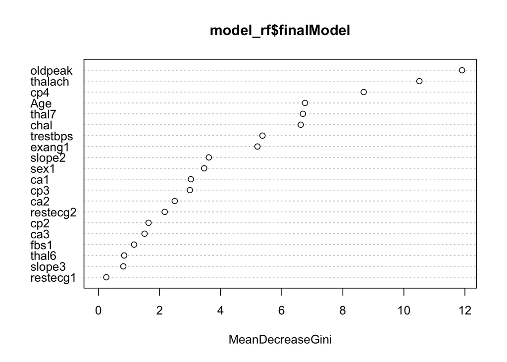

```r
varImpPlot(model_rf$finalModel)
```

$\bullet$ Kurulan random forest modeli için en önemli değişkenler: thalach ve oldpeak değişkenleridir.

## 2.4 DESTEK VEKTÖR MAKİNESİ (SVM) MODELİ:

```r
set.seed(123)
model_svm <- train(num~.,data = trainSet,trControl=train_control,method="svmRadialSigma",preProc=c("center","scale"),
                   tuneLength=10,metric="ROC")
model_svm
```

```
## Support Vector Machines with Radial Basis Function Kernel
##
## 213 samples
##  13 predictor
##   2 classes: 'YES', 'NO'
##
## Pre-processing: centered (20), scaled (20)
## Resampling: Cross-Validated (10 fold)
## Summary of sample sizes: 191, 191, 192, 193, 191, 192, ...
## Resampling results across tuning parameters:
##
##   sigma       C       ROC        Sens       Spec
##   0.01659226    0.25  0.9207071  0.8266667  0.8325758
##   0.01659226    0.50  0.9195707  0.7855556  0.8590909
##   0.01659226    1.00  0.9144697  0.7955556  0.8871212
##   0.01659226    2.00  0.9082576  0.7955556  0.8606061
##   0.01659226    4.00  0.9115657  0.7844444  0.8795455
##   0.01659226    8.00  0.9046212  0.8144444  0.8545455
##   0.01659226   16.00  0.8851010  0.7644444  0.8204545
##   0.01659226   32.00  0.8660606  0.7344444  0.8272727
##   0.01659226   64.00  0.8541162  0.7644444  0.8280303
##   0.01659226  128.00  0.8560606  0.7444444  0.8356061
##   0.02242687    0.25  0.9186869  0.8066667  0.8416667
##   0.02242687    0.50  0.9168939  0.7855556  0.8507576
##   0.02242687    1.00  0.9117677  0.7955556  0.8606061
##   0.02242687    2.00  0.9096717  0.8166667  0.8704545
##   0.02242687    4.00  0.9116162  0.8044444  0.8628788
##   0.02242687    8.00  0.8923737  0.7644444  0.8371212
##   0.02242687   16.00  0.8706566  0.7444444  0.8280303
##   0.02242687   32.00  0.8583081  0.7444444  0.8022727
##   0.02242687   64.00  0.8568939  0.7744444  0.8446970
##   0.02242687  128.00  0.8568182  0.7644444  0.8265152
##   0.02826148    0.25  0.9116919  0.8066667  0.8500000
##   0.02826148    0.50  0.9149747  0.8066667  0.8598485
##   0.02826148    1.00  0.9127525  0.8266667  0.8424242
##   0.02826148    2.00  0.9112121  0.8266667  0.8621212
##   0.02826148    4.00  0.9016919  0.7844444  0.8537879
##   0.02826148    8.00  0.8852273  0.7444444  0.8371212
##   0.02826148   16.00  0.8662374  0.7744444  0.8106061
##   0.02826148   32.00  0.8583081  0.7644444  0.8265152
```

[output cut: 20 more lines]

```
##   0.03993069   64.00  0.8643182  0.7755556  0.8265152
##   0.03993069  128.00  0.8643182  0.7544444  0.8272727
##   0.04576530    0.25  0.9144697  0.8066667  0.8507576
##   0.04576530    0.50  0.9132576  0.8166667  0.8689394
##   0.04576530    1.00  0.9113636  0.8266667  0.8704545
##   0.04576530    2.00  0.9041919  0.8277778  0.8446970
##   0.04576530    4.00  0.8913131  0.7755556  0.8287879
##   0.04576530    8.00  0.8789141  0.7955556  0.8106061
##   0.04576530   16.00  0.8667172  0.7855556  0.8272727
##   0.04576530   32.00  0.8657071  0.7855556  0.8181818
##   0.04576530   64.00  0.8657071  0.7855556  0.8272727
##   0.04576530  128.00  0.8657071  0.7855556  0.8189394
##
## ROC was used to select the optimal model using the largest value.
## The final values used for the model were sigma = 0.01659226 and C = 0.25.
```

```r
set.seed(123)
model_svm_linear <- train(num~.,data = trainSet,trControl=train_control,method="svmLinear",preProc=c("center","scale"),
                   tuneLength=10,metric="ROC")
model_svm_linear
```

```
## Support Vector Machines with Linear Kernel
##
## 213 samples
##  13 predictor
##   2 classes: 'YES', 'NO'
##
## Pre-processing: centered (20), scaled (20)
## Resampling: Cross-Validated (10 fold)
## Summary of sample sizes: 191, 191, 192, 193, 191, 192, ...
## Resampling results:
##
##   ROC        Sens       Spec
##   0.9137374  0.7655556  0.8704545
##
## Tuning parameter 'C' was held constant at a value of 1
```

## 3.MODEL SEÇİMİ:

## 3.1 ÇAPRAZ DOĞRULAMAYA GÖRE DEĞERLENDİRME:

$\bullet$ En iyi modeli seçerken, çapraz doğrulama seferlerinin tamamını dikkate alındığında, en yüksek ortalama AUC’ye sahip modeli seçilir. Ancak aynı zamanda, bu AUC’lerin düşük standart sapmaya sahip olması istenen bir başka özelliktir. caret paketinde resamples() fonksiyonu, bu prensipleri modelleri seçerken uygulamamızı sağlar.

```r
resamps <- resamples(list(SVM=model_svm,RF=model_rf,LOGREG=model_logreg_final))
summary(resamps)
```

```
##
## Call:
## summary.resamples(object = resamps)
##
## Models: SVM, RF, LOGREG
## Number of resamples: 10
##
## ROC
##             Min.   1st Qu.    Median      Mean   3rd Qu.      Max. NA's
## SVM    0.8083333 0.9037879 0.9313131 0.9207071 0.9465909 0.9909091    0
## RF     0.7916667 0.9078283 0.9390152 0.9247727 0.9534091 0.9818182    0
## LOGREG 0.7878788 0.8229167 0.9131313 0.8924747 0.9581439 0.9666667    0
##
## Sens
##             Min.   1st Qu.    Median      Mean   3rd Qu. Max. NA's
## SVM    0.7000000 0.7833333 0.8000000 0.8266667 0.8972222  1.0    0
## RF     0.6000000 0.6750000 0.7388889 0.7544444 0.8000000  1.0    0
## LOGREG 0.5555556 0.6250000 0.7888889 0.7533333 0.8750000  0.9    0
##
## Spec
##             Min.   1st Qu.    Median      Mean   3rd Qu. Max. NA's
## SVM    0.6363636 0.7500000 0.8636364 0.8325758 0.9166667    1    0
## RF     0.7500000 0.8219697 0.9090909 0.8780303 0.9147727    1    0
## LOGREG 0.5454545 0.7329545 0.8333333 0.8007576 0.9090909    1    0
```

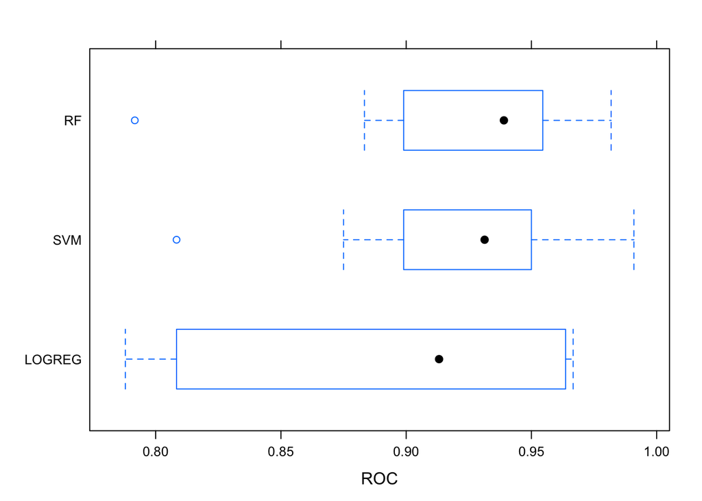

```r
bwplot(resamps,metric="ROC")
```

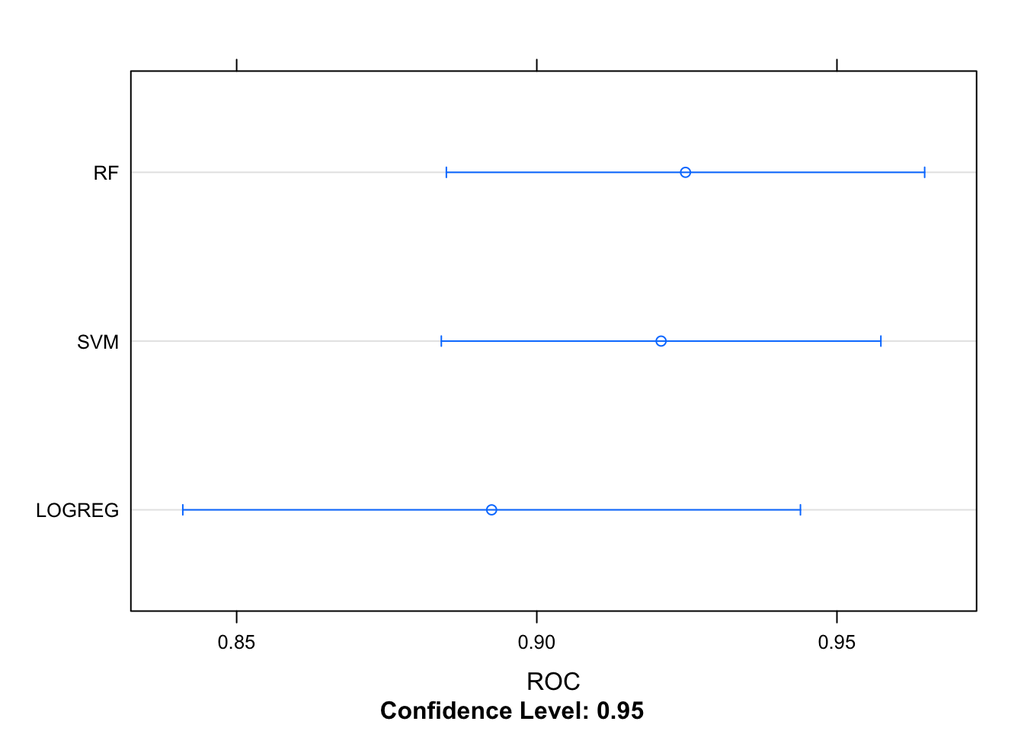

```r
dotplot(resamps,metric="ROC")
```

## 3.2 TEST SETİ İLE DEĞERLENDİRİLMESİ:

## 3.2.1 HATA MATRİSİ:

```r
logreg_test <- predict(model_logreg_final,newdata=testSet)
confusionMatrix(data=logreg_test,testSet$num)
```

```
## Confusion Matrix and Statistics
##
##           Reference
## Prediction YES NO
##        YES  31  9
##        NO   10 40
##
##                Accuracy : 0.7889
##                  95% CI : (0.6901, 0.8679)
##     No Information Rate : 0.5444
##     P-Value [Acc > NIR] : 1.206e-06
##
##                   Kappa : 0.5736
##
##  Mcnemar's Test P-Value : 1
##
##             Sensitivity : 0.7561
##             Specificity : 0.8163
##          Pos Pred Value : 0.7750
##          Neg Pred Value : 0.8000
##              Prevalence : 0.4556
##          Detection Rate : 0.3444
##    Detection Prevalence : 0.4444
##       Balanced Accuracy : 0.7862
##
##        'Positive' Class : YES
##
```

$\bullet$ accuracy=%78 doğru tahmin yapabiliyoruz.

$\bullet$ Sensivitiy = TP/(TP+FN) Model gerçekte kalp rahatsızlığı olanların %75’ni doğru tahmin edebilmektedir.

$\bullet$ Specificity = TN/(FP+TN) Model gerçekte kalp rahatsızlığı olamayanların %81’ni doğru tahmin edebilmektedir.

```r
rf_test <- predict(model_rf,newdata = testSet)
confusionMatrix(data = rf_test,testSet$num)
```

```
## Confusion Matrix and Statistics
##
##           Reference
## Prediction YES NO
##        YES  31  7
##        NO   10 42
##
##                Accuracy : 0.8111
##                  95% CI : (0.7149, 0.8859)
##     No Information Rate : 0.5444
##     P-Value [Acc > NIR] : 1.061e-07
##
##                   Kappa : 0.6169
##
##  Mcnemar's Test P-Value : 0.6276
##
##             Sensitivity : 0.7561
##             Specificity : 0.8571
##          Pos Pred Value : 0.8158
##          Neg Pred Value : 0.8077
##              Prevalence : 0.4556
##          Detection Rate : 0.3444
##    Detection Prevalence : 0.4222
##       Balanced Accuracy : 0.8066
##
##        'Positive' Class : YES
##
```

$\bullet$ accuracy=%81 doğru tahmin yapabiliyoruz.

$\bullet$ Sensivitiy = TP/(TP+FN) Model gerçekte kalp rahatsızlığı olanların %75’ni doğru tahmin edebilmektedir.

$\bullet$ Specificity = TN/(FP+TN) Model gerçekte kalp rahatsızlığı olamayanların %85’nu doğru tahmin edebilmektedir.

```r
svm_test <- predict(model_svm,newdata = testSet)
confusionMatrix(data=svm_test,testSet$num)
```

```
## Confusion Matrix and Statistics
##
##           Reference
## Prediction YES NO
##        YES  32  5
##        NO    9 44
##
##                Accuracy : 0.8444
##                  95% CI : (0.7528, 0.9123)
##     No Information Rate : 0.5444
##     P-Value [Acc > NIR] : 1.629e-09
##
##                   Kappa : 0.6839
##
##  Mcnemar's Test P-Value : 0.4227
##
##             Sensitivity : 0.7805
##             Specificity : 0.8980
##          Pos Pred Value : 0.8649
##          Neg Pred Value : 0.8302
##              Prevalence : 0.4556
##          Detection Rate : 0.3556
##    Detection Prevalence : 0.4111
##       Balanced Accuracy : 0.8392
##
##        'Positive' Class : YES
##
```

$\bullet$ accuracy=%84 doğru tahmin yapabiliyoruz.

$\bullet$ Sensivitiy = TP/(TP+FN) Model gerçekte kalp rahatsızlığı olanların %78’ni doğru tahmin edebilmektedir.

$\bullet$ Specificity = TN/(FP+TN) Model gerçekte kalp rahatsızlığı olamayanların %89’nu doğru tahmin edebilmektedir.

$\bullet$ Accuracy değerlerine bakıldığında destek vektör makinesi modelinin %84 ile en doğru yöntem olduğu görülmektedir.

## 3.2.2 SINIF OLASILIKLARI VE TAHMİNLERİ:

```r
logreg_test_prob <- predict(model_logreg_final,testSet,type="prob")
tahminler <- cbind(logreg_test_prob,logreg_test)
head(tahminler)
```

```
##           YES         NO logreg_test
## 2  0.98321945 0.01678055         YES
## 3  0.98749983 0.01250017         YES
## 4  0.24502141 0.75497859          NO
## 5  0.01025368 0.98974632          NO
## 6  0.06292230 0.93707770          NO
## 10 0.54236166 0.45763834         YES
```

```r
#hasta olarak tahmin edilen test veri seti gözlemlerinin filtrelenmesi:
hasta_tahmin <- tahminler[which(tahminler["logreg_test"]=="YES"),]
range(hasta_tahmin["YES"])
```

```
## [1] 0.5242234 0.9912829
```

```r
hastano_tahmin <- tahminler[which(tahminler["logreg_test"]=="NO"),]
range(hastano_tahmin["NO"])
```

```
## [1] 0.5042803 0.9897463
```

$\bullet$ Tahmin hasta(yani yes) olduğunda yes(hasta) olma olasılıkları 0.52 ile 0.99 arasında değiştiğini anlıyoruz.

$\bullet$ Tahmin hasta olmayan (yani no) olduğunda no(hasta olmamama) olma olasılıkları 0.50 ile 0.98 arasında değiştiğini görüyoruz.

```r
rf_test_prob <- predict(model_rf,testSet,type="prob")
tahminler_rf <- cbind(rf_test_prob,rf_test)
head(tahminler_rf)
```

```
##      YES    NO rf_test
## 2  0.876 0.124     YES
## 3  0.940 0.060     YES
## 4  0.318 0.682      NO
## 5  0.054 0.946      NO
## 6  0.088 0.912      NO
## 10 0.762 0.238     YES
```

```r
#hasta olarak tahmin edilen test veri seti gözlemlerinin filtrelenmesi:
hasta_tahmin_rf <- tahminler_rf[which(tahminler_rf["rf_test"]=="YES"),]
range(hasta_tahmin_rf["YES"])
```

```
## [1] 0.506 0.942
```

```r
hastano_tahmin_rf <- tahminler_rf[which(tahminler_rf["rf_test"]=="NO"),]
range(hastano_tahmin_rf["NO"])
```

```
## [1] 0.510 0.996
```

$\bullet$ Tahmin hasta(yani yes) olduğunda yes(hasta) olma olasılıkları 0.50 ile 0.94 arasında değiştiğini anlıyoruz.

$\bullet$ Tahmin hasta olmayan (yani no) olduğunda no(hasta olmamama) olma olasılıkları 0.51 ile 0.99 arasında değiştiğini görüyoruz.

```r
svm_test_prob <- predict(model_svm,testSet,type="prob")
tahminler_svm <- cbind(svm_test_prob,svm_test)
head(tahminler_svm)
```

```
##          YES         NO svm_test
## 1 0.97848209 0.02151791      YES
## 2 0.98947366 0.01052634      YES
## 3 0.23415552 0.76584448       NO
## 4 0.03460238 0.96539762       NO
## 5 0.02772758 0.97227242       NO
## 6 0.90239013 0.09760987      YES
```

```r
#hasta olarak tahmin edilen test veri seti gözlemlerinin filtrelenmesi:
hasta_tahmin_svm <- tahminler_svm[which(tahminler_svm["svm_test"]=="YES"),]
range(hasta_tahmin_svm["YES"])
```

```
## [1] 0.5519931 0.9894737
```

```r
hastano_tahmin_svm <- tahminler_svm[which(tahminler_svm["svm_test"]=="NO"),]
range(hastano_tahmin_svm["NO"])
```

```
## [1] 0.5152523 0.9864349
```

$\bullet$ Tahmin hasta(yani yes) olduğunda yes(hasta) olma olasılıkları 0.55 ile 0.98 arasında değiştiğini anlıyoruz.

$\bullet$ Tahmin hasta olmayan (yani no) olduğunda no(hasta olmamama) olma olasılıkları 0.51 ile 98 arasında değiştiğini görüyoruz.

## 3.2.3 ROC EĞRİSİ VE AUC DEĞERİ:

```r
library(ROCR)
```

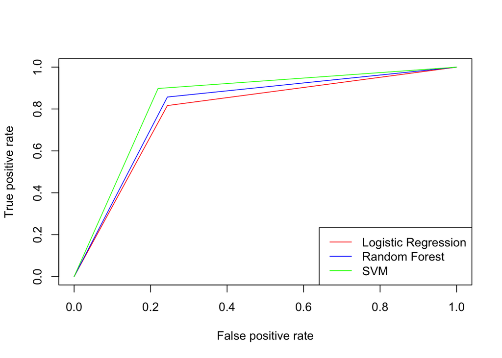

```r
pr.log <-prediction(as.numeric(logreg_test),as.numeric(testSet$num))
prf.log <- performance(pr.log,measure="tpr",x.measure="fpr")
plot(prf.log,col="red")

pr.bag.rf <- prediction(as.numeric(rf_test), as.numeric(testSet$num))
prf.bag.rf<- performance(pr.bag.rf, measure = "tpr", x.measure = "fpr")
plot(prf.bag.rf, col="blue", add=TRUE)

pr.svm<- prediction(as.numeric(svm_test),as.numeric(testSet$num))
prf.svm<- performance(pr.svm, measure = "tpr", x.measure = "fpr")
plot(prf.svm, col="green", add=TRUE)

legend("bottomright",legend=c("Logistic Regression","Random Forest","SVM"),lty=c(1,1),
       col=c("red","blue","green"))
```

```r
auc.log <- performance(pr.log,measure="auc")
auc.log <- auc.log@y.values[[1]]
auc.log
```

```
## [1] 0.786212
```

```r
auc.bag.rf <- performance(pr.bag.rf, measure = "auc")
auc.bag.rf <- auc.bag.rf@y.values[[1]]
auc.bag.rf
```

```
## [1] 0.8066202
```

```r
auc.svm <- performance(pr.svm,measure = "auc")
auc.svm <- auc.svm@y.values[[1]]
auc.svm
```

```
## [1] 0.8392235
```

$\bullet$ Uygulanan her üç modele ait ROC eğrisini tek bir grafik üstünde gösterildi ve eğri altında kalan(AUC) hesaplaması yapıldı.

$\bullet$ Eğri altında kalan(AUC) değerlerine göre de en uygun modelin destek vektör makinesi ile elde edilen model_svm olduğu belirlenmiştir.(Lojistik regresyon=0.78, Random Forest=0.80, Destek Vektör Makinesi=0.83)